# R Notebook

```r
library(tidyverse)
library(brms)
library(lme4)
library(lmerTest)
library(plotrix)
library(stringr)
library(readxl)
library(RColorBrewer)
library(Hmisc)
library("wesanderson")
```

```r
base = read.csv("vbd_only_base.csv") %>%
  select(-X, -vb_freq, -total_freq, -vbn_freq)
d = read.csv("argstruct-vbdonly_items.csv", header=FALSE) %>%
  rename("word" = V1) %>%
  rename("verb" = V2) %>%
  rename("pos" = V3) %>%
  rename("freq" = V4) %>%
  rename("is_trans" = V5) %>%
  rename("is_intrans" = V6) %>%
  rename("gram" = V7) %>%
  rename("target_id" = V8) %>%
  rename("item_number" = V9) %>%
  rename("test" = V10)
lstm_results = read.csv("argstruct-vbdonly_lstm_output.txt", sep="\t", header=FALSE) %>%
  rename("word_1" = V1) %>%
  rename("surprisal" = V2) %>%
  mutate(sent = if_else(word_1 == "<eos>", 1, 0)) %>%
  mutate(sent = cumsum(sent)) %>%
  mutate(sent_pos = 1) %>%
  group_by(sent) %>%
    mutate(sent_pos = cumsum(sent_pos)) %>%
  ungroup() %>%
  select(-sent) %>%
  mutate(sent_pos = sent_pos - 2) %>%
  filter(word_1 != "<eos>") %>%
  mutate(model = "lstm")
rnng_results = read.csv("argstruct-vbdonly_rnng_output.txt", sep="\t", header=FALSE) %>%
  rename("word_1" = V1) %>%
  rename("surprisal" = V2) %>%
  mutate(sent = if_else(word_1 == "<eos>", 1, 0)) %>%
  mutate(sent = cumsum(sent)) %>%
  mutate(sent_pos = 1) %>%
  group_by(sent) %>%
    mutate(sent_pos = cumsum(sent_pos)) %>%
  ungroup() %>%
  select(-sent) %>%
  mutate(sent_pos = sent_pos - 2) %>%
  filter(word_1 != "<eos>") %>%
  mutate(model = "rnng")
action_results = read.csv("argstruct-vbdonly_action_output.txt", sep="\t", header=FALSE) %>%
  rename("word_1" = V1) %>%
  rename("surprisal" = V2) %>%
  mutate(sent = if_else(word_1 == "<eos>", 1, 0)) %>%
  mutate(sent = cumsum(sent)) %>%
  mutate(sent_pos = 1) %>%
  group_by(sent) %>%
    mutate(sent_pos = cumsum(sent_pos)) %>%
  ungroup() %>%
  select(-sent) %>%
  mutate(sent_pos = sent_pos - 2) %>%
  filter(word_1 != "<eos>") %>%
  mutate(model = "actionLstm")
v_counts = read_csv("../data/v_counts.csv") %>%
  rename("freq" = `0`) %>%
  select(-X1, -LEMMA) %>%
  spread(XPOS, freq) %>%
  replace(is.na(.), 0) %>%
  mutate(total = VBD + VBN,
         percent_VBD = VBD/total,
         percent_VBN = VBN/total) %>%
  rename("word" = WORD)
```

```r
d_lstm = merge(d, lstm_results, by=0, all=TRUE)
d_rnng = merge(d, rnng_results, by=0, all=TRUE)
d_action = merge(d, action_results, by=0, all=TRUE)
d_agg = rbind( d_lstm, d_rnng, d_action)
d_agg = d_agg %>%
  arrange(as.numeric(Row.names)) %>%
  filter((target_id-1 == sent_pos) | (target_id-2 == sent_pos) | (target_id-3 == sent_pos)) %>%
  filter( !((target_id-3 == sent_pos) & (test=="base-nomod")) ) %>%
  filter( !((target_id-3 == sent_pos) & (test=="base-pres")) ) %>%
  group_by(model, verb, pos, is_trans, is_intrans, gram, test, freq, item_number) %>%
    summarise(surprisal = sum(surprisal)) %>%
  ungroup() %>%
  spread(gram, surprisal) %>%
  mutate(obj_exp = nobj-obj) %>%
  select(-obj, -nobj) %>%
  mutate(is_trans = if_else(((is_trans=="Y") & (is_intrans=="Y")), "Ambitrans", as.character(is_trans))) %>%
  mutate(is_trans = if_else(is_trans == "Y", "Trans", is_trans)) %>%
  mutate(is_trans = if_else(is_trans == "N", "Intrans", is_trans)) %>%
  mutate(model = factor(model, levels = c("5gram", "lstm", "actionLstm", "rnng"))) %>%
  select(-is_intrans, -freq, -pos)

d_agg =  merge(d_agg, v_counts, by.x="verb", by.y = "word") %>%
  mutate(total = if_else(total > 100, 100, total)) %>%
  mutate(VB = if_else(VB > 100, 100, VB)) %>%
  mutate(VBD = if_else(VBD > 100, 100, VBD)) %>%
  mutate(VBN = if_else(VBN > 100, 100, VBN)) %>%
  mutate(vbd_freq = "100") %>%
  mutate(vbd_freq = if_else(VBD<=50, "50", vbd_freq)) %>%
  mutate(vbd_freq = if_else(VBD<=30, "30", vbd_freq)) %>%
  mutate(vbd_freq = if_else(VBD<=20, "20", vbd_freq)) %>%
  mutate(vbd_freq = if_else(VBD<=10, "10", vbd_freq)) %>%
  mutate(vbd_freq = if_else(VBD<=5, "5", vbd_freq)) %>%
  mutate(vbd_freq = if_else(VBD<=3, "3", vbd_freq)) %>%
  mutate(vbd_freq = if_else(VBD<=2, "2", vbd_freq)) %>%
  mutate(vbd_freq = if_else(VBD<=1, "1", vbd_freq)) %>%
  mutate(vbd_freq = if_else(VBD<=0, "0", vbd_freq)) %>%
  mutate(vbd_freq = factor(vbd_freq, levels = c("0", "1", "2", "3", "5", "10", "20", "30", "50", "100")))
d_agg = rbind(d_agg, base)
```

```r
write.csv(d_agg, "arg_transf.csv")
```

## Transformations

### Test Items

Now, we look at the learning rate for the transformed test, for verbs that occur *only* in the active contexts in the training data. I have to clip for verbs that occur only 10 or fewer times, because there weren’t many intransitive and transitive verbs that occured only in the active context (the PTB has a lot of passive voice!).

• The gazelle was (quickly and rapidly) devoured yesterday . [object]

• The gazelle (quickly and rapidly) devoured yesterday . [no-object]

Predictions: If the model is able to learn something about verbal argument structure, then we expect our previos predictions to hold

1. The object expectation for transitive should be greater than for intransitive verbs.
2. The object expectation should be positive for transitive verbs (it is more likely to occur with a passive object than without an object)
3. The object expectation should be negative for intransitive verbs (it is more likely to occur without an object than with a passive object)

### Results

LSTM Baseline:

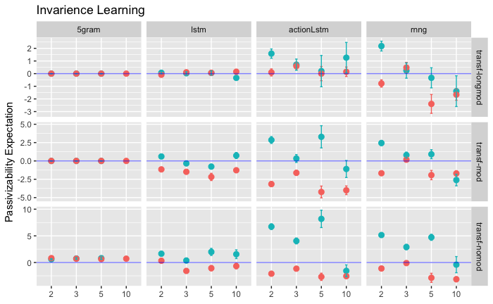

```r
d_agg %>%
  filter(VBN == 0, test=="transf-nomod" | test == "transf-mod" | test == "transf-longmod", is_trans != "Ambitrans") %>%
  filter(vbd_freq != "20" & vbd_freq != "100") %>%
  group_by(model, is_trans, test, vbd_freq) %>%
    summarise(m = mean(obj_exp),
              s=std.error(obj_exp),
              upper=m+1.96*s,
              lower=m-1.96*s)%>%
  ungroup() %>%
  ggplot(aes(x=vbd_freq, y=m, ymin=lower, ymax=upper, color=is_trans)) +
    geom_point(stat="identity", position="dodge", size=2.5) +
    geom_errorbar(width=.1) +
    geom_hline(yintercept=0, color="blue", alpha=0.5) +
    ylab("Passivizability Expectation") +
    xlab("Frequency in VBD Contexts") +
    ggtitle("Invarience Learning") +
    facet_grid(test ~ model, scales = "free") +
    theme(axis.title.x=element_blank(),
          legend.position = "none")
ggsave("../images/argstruct-invar.png",height=3.5,width=6)
```

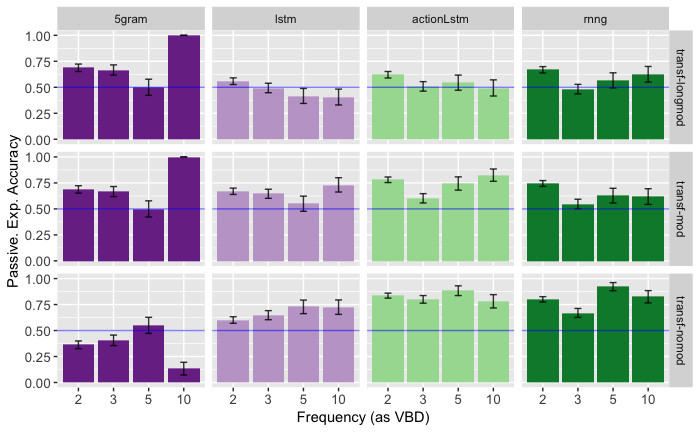

```r
d_agg %>%
  #filter(VBN == 0, test=="transf-nomod") %>%
  #filter(VBN == 0, test=="transf-nomod" | test == "transf-mod", is_trans != "Ambitrans") %>%
  #filter(vbd_freq == "2" | vbd_freq == "3" | vbd_freq == "5" | vbd_freq == "10") %>%
  filter(vbd_freq != "20" & vbd_freq != "100") %>%
  mutate(obj_exp = if_else(obj_exp > 0, 1, 0)) %>%
  mutate(obj_exp = if_else(is_trans == "Intrans", 1-obj_exp, obj_exp)) %>%

  group_by(model, test, vbd_freq) %>%
    summarise(m = mean(obj_exp),
              s=std.error(obj_exp),
              upper=m+1.96*s,
              lower=m-1.96*s)%>%
  ungroup() %>%
  ggplot(aes(x=vbd_freq, y=m, ymin=lower, ymax=upper, fill=model)) +
    geom_bar(stat="identity", position="dodge", size=3) +
    geom_errorbar(position=position_dodge(width=0.9), width=.2, alpha=0.8) +
    geom_hline(yintercept=0.5, color="blue", alpha=0.5) +
    ylab("Passive. Exp. Accuracy ") +
    xlab("Frequency (as VBD)") +
    #ggtitle("Invarience") +
    facet_grid(test~model) +
    #ylim(0,1) +
    scale_fill_brewer(palette="PRGn") +
    #scale_fill_manual(values = wes_palette("Zissou")) +
    theme(axis.text=element_text(size=10),
          legend.position = "none")
ggsave("../images/argstruct-invar-acc.png",height=3.5,width=6)
```

[output not shown]